# Notas de Clase: ¿Son distintos estos grupos?

El encargo de la secretaría de educación del Atlántico · comparar cinco módulos al tiempo

Estadística Multidimensional · Universidad Distrital Francisco José de Caldas

Sábado 7 de noviembre de 2026 · notas para leer por su cuenta

# 1 Cómo leer estas notas

Hoy **no hay clase en vivo**. Estas notas están escritas para que las lean solos, en orden, con R abierto. Calculen unas **dos horas**.

- Corran cada bloque de código a medida que avanzan. Todos los números del texto salen de ahí.
- Cada tanto van a encontrar un recuadro **✋ Deténgase aquí y responda**. Escriban su respuesta **antes** de abrir la respuesta. No cuenta para nota; sirve para saber si entendieron antes de seguir.
- Cada sección empieza con **una pregunta de la secretaría** y termina con **lo que la secretaría decide**. Si al terminar una sección no saben qué decide la secretaría, vuelvan a leerla.
- Al final está el **taller para entregar** en Moodle, sobre el dataset de su equipo. Las dudas se resuelven en los primeros 20 minutos de la clase del **lunes 9 de noviembre**.

# 2 Introducción: el encargo

Esta vez el cliente es **la secretaría de educación del Atlántico** (es un supuesto de la clase: los datos son reales, el encargo lo imaginamos). Su equipo de calidad educativa recibe los resultados de la prueba Saber de los técnicos y tecnólogos del departamento, y nos escribe:

> *«Tenemos que presentar el informe del año al gobernador. Necesitamos saber dos cosas. Primero: ¿nuestros estudiantes rinden distinto de los del país? No en un módulo: en los cinco. Y segundo: vamos a diseñar un programa de orientación vocacional. ¿Hombres y mujeres llegan con perfiles distintos, o da igual?»*

Las dos son la misma pregunta de fondo: **¿este grupo es distinto de aquel, mirando los cinco módulos al tiempo?** Y la respuesta que le sirve a la secretaría tiene **tres partes**. Casi todos los informes se quedan en la primera:

1. **¿Es real?** ¿O puede ser mala suerte de este grupo de estudiantes?
2. **¿Es grande?** ¿Cuánto es, en algo que el gobernador entienda?
3. **¿Separa?** Si me dan los puntajes de un estudiante, ¿puedo saber de qué grupo es?

# 3 Objetivos de aprendizaje

Al terminar, cada estudiante debe poder:

1. Explicar por qué **comparar módulo por módulo no alcanza** cuando los módulos se mueven juntos.
2. Medir **qué tan lejos** están dos grupos, en unidades que se entiendan.
3. Distinguir **una diferencia real** de **una diferencia grande**, y las dos de **una diferencia que separa**.
4. Traducir el resultado a **una decisión para el cliente**, y decir qué no se puede concluir.

# 4 La base con la que llegamos

La misma limpieza de las sesiones anteriores.

```r
saber <- read.csv("PruebaSaber1.csv", sep = ";", fileEncoding = "latin1",
                  stringsAsFactors = FALSE)

s <- saber |>
  transmute(
    cuantitativo = MOD_RAZONA_CUANTITAT_PUNT,
    lectura      = MOD_LECTURA_CRITICA_PUNT,
    ciudadanas   = MOD_COMPETEN_CIUDADA_PUNT,
    ingles       = MOD_INGLES_PUNT,
    escritura    = MOD_COMUNI_ESCRITA_PUNT,
    global       = PUNT_GLOBAL,
    estrato      = FAMI_ESTRATOVIVIENDA,
    genero       = ESTU_GENERO,
    depto        = ESTU_DEPTO_RESIDE
  )
s$id <- seq_len(nrow(s))

modulos  <- c("cuantitativo", "lectura", "ciudadanas", "ingles", "escritura")
etiqueta <- c(cuantitativo = "cuantitativo", lectura = "lectura", ciudadanas = "ciudadanas",
              ingles = "inglés", escritura = "escritura")

s <- s[s$estrato != "Empleado obrero u operario", ]          # fila corrida
s$ingles[s$ingles == 0] <- NA                                 # no presentaron inglés
for (m in modulos) s[[m]][s$id %in% c(671, 614) & s[[m]] == 0] <- NA

sc <- s[complete.cases(s[modulos]), ]
sc$genero  <- factor(sc$genero, levels = c("F", "M"), labels = c("Mujer", "Hombre"))
sc$estrato <- sub("Estrato ", "", sc$estrato)
sc$estrato[sc$estrato %in% c("4", "5", "6")] <- "4 a 6"

X  <- as.matrix(sc[modulos])
mu <- colMeans(X)          # el promedio del país: toda la base
nrow(sc)
```

```
## [1] 9907
```

Trabajamos con los 9 907 estudiantes que tienen los cinco módulos. **El promedio de toda la base es nuestra referencia del país.** Ojo: es el promedio de esta base, no una cifra oficial publicada; en el informe se dice así.

# 5 Primera pregunta: «¿Nuestros estudiantes rinden menos que los del país?»

## 5.1 Módulo por módulo

**La secretaría pregunta:** *«¿En qué módulos estamos por debajo?»*

```r
atl <- sc$depto == "ATLANTICO"
Xa  <- X[atl, ]
na  <- nrow(Xa)
dif_atl <- colMeans(Xa) - mu
round(rbind(pais = mu, atlantico = colMeans(Xa), diferencia = dif_atl), 1)
```

```
##            cuantitativo lectura ciudadanas ingles escritura
## pais              100.1   100.1      100.1  100.1     100.3
## atlantico          95.1    93.9       93.0   97.0      94.9
## diferencia         -5.0    -6.2       -7.1   -3.1      -5.4
```

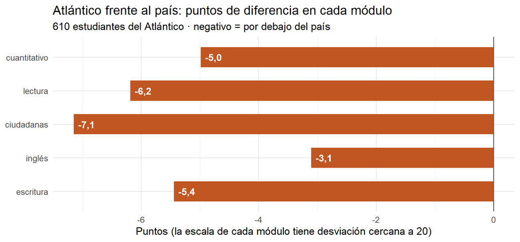

```r
data.frame(modulo = factor(etiqueta[modulos], levels = rev(etiqueta)), dif = dif_atl) |>
  ggplot(aes(dif, modulo)) +
  geom_col(fill = "#C05621", width = 0.6) +
  geom_vline(xintercept = 0, color = "grey40") +
  geom_text(aes(label = coma(dif)), hjust = -0.25, color = "white", fontface = "bold", size = 4.2) +
  scale_x_continuous(labels = function(x) coma(x, 0)) +
  labs(title = "Atlántico frente al país: puntos de diferencia en cada módulo",
       subtitle = paste0(miles(na), " estudiantes del Atlántico · negativo = por debajo del país"),
       x = "Puntos (la escala de cada módulo tiene desviación cercana a 20)", y = NULL)
```

> 📋 **Describir:** los 610 estudiantes del Atlántico están por debajo del país en los cinco módulos, entre 3,1 y 7,1 puntos.

> 🔎 **Analizar:** la dirección es clara, pero cinco cifras sueltas no le dicen al gobernador **cuánto** es eso. Y hay una trampa: los módulos se mueven juntos —lectura y ciudadanas van 0,64, como vimos en componentes principales—, así que estar por debajo en lectura y en ciudadanas **no son dos hallazgos, es casi uno contado dos veces**. **Decisión de la secretaría:** no presentar cinco barras sueltas; pedir **una sola medida** de cuánto se aleja el departamento, con los cinco módulos al tiempo.

## 5.2 «¿Cuánto es eso, en algo que se entienda?»

**La secretaría pregunta:** *«¿Estar 5 puntos abajo es mucho o poco?»*

Depende de **cuánto varían los estudiantes**. Cinco puntos en una prueba donde todos sacan casi lo mismo es una brecha enorme; en una donde los estudiantes van de 40 a 160, es poco. Por eso la diferencia se mide **en unidades de variación**.

> 📐 **La matemática, enunciada.** Con un solo módulo, la distancia entre el Atlántico y el país es

> $$\text{distancia} = \frac{\text{promedio
> del Atlántico} - \text{promedio del país}}{\text{cuánto varían los
> estudiantes (desviación)}}$$

> **En palabras:** cuántas «desviaciones» separan los dos promedios. Una distancia de 1 es una desviación completa: muchísimo. Una de 0,1 es una brecha que casi no se ve.

> **Con los cinco módulos se hace lo mismo**, con un ajuste: se descuenta que los módulos se mueven juntos, para no contar dos veces la misma brecha. Es exactamente la distancia de Mahalanobis de la sesión 2, pero aplicada **al promedio del grupo** en vez de a un estudiante. La llamamos $D$.

```r
D2_atl <- as.numeric(t(dif_atl) %*% solve(cov(Xa)) %*% dif_atl)
D_atl  <- sqrt(D2_atl)
round(D_atl, 3)
```

```
## [1] 0.423
```

> 📋 **Describir:** el promedio del Atlántico está a 0,42 desviaciones del promedio del país, contando los cinco módulos al tiempo.

> 🔎 **Analizar:** menos de media desviación. Es una distancia **moderada**: se nota, pero el estudiante típico del Atlántico se parece mucho más al del país de lo que se diferencia. **Decisión de la secretaría:** en el informe dice «estamos por debajo del país a menos de media desviación en los cinco módulos», no «estamos muy por debajo». Falta saber si no es mala suerte.